# Weight-for-height Z-score in Bangladeshi infants aged 6-13 months

Dataset 7: Bangladesh growth monitoring and promotion survey

RSR feasibility analysis

2026-08-03

# Introduction

The data come from a cross-sectional household survey in rural Bangladesh that compared two ways of delivering growth monitoring and promotion (GMP): sessions held at a community clinic (“facility-based”) and sessions held in the community/home (“home-based”). Caregivers of 3038 young children across six upazilas were interviewed and the children were weighed and measured (source paper: PLOS ONE, e0324918). Weight-for-height Z-score (WHZ) captures *acute* undernutrition — thinness relative to length — and is the index most responsive to recent food shortage and illness, so in principle it is the outcome most likely to move on a short timescale in response to a programme.

**Aim.** Among rural Bangladeshi infants aged 6-13 months, we examined which of GMP delivery model, child sex, child age, mother’s age, mother’s schooling, household asset tertile, NGO membership and toilet quality are independently associated with weight-for-height Z-score, mutually adjusting for the others.

This is a *Purpose 3* analysis: several predictors are of interest and the question is which remain associated with the outcome after mutual adjustment.

# Methods

**Data source.** Cross-sectional survey of 3038 caregiver-child pairs in six rural upazilas of Bangladesh. The study sampled 60 community-clinic catchment areas, arranged as matched pairs, one area of each pair receiving facility-based and the other home-based GMP. The file supplied for this catalogue contains one row per child.

**Variables.** The outcome is `weight_for_height_z`, the WHO weight-for-height Z-score in standard-deviation units; more negative values mean thinner children for their length. Predictors are: GMP delivery model (facility-based = reference, home-based); child sex (male = reference); child age in months (continuous, observed range 6.0 to 13.0); mother’s age in years (continuous); mother’s completed schooling in years (continuous); household asset index tertile (lowest = reference, middle, highest); NGO membership (no = reference); and improved toilet facility (no = reference).

*Near-constant variables dropped.* `mother_occupation` is 97.5% “housewife” and `religion_muslim` is 97.8% Muslim; both were left out of the main model and are shown in a sensitivity fit in the feasibility notes.

*Other Z-scores excluded.* `weight_for_age_z` and `height_for_age_z` are not predictors. Weight-for-height is computed from the same weight and length measurements, so regressing it on either is an arithmetic exercise, not an epidemiological one.

**Statistical analysis.** Linear regression via `lm()`, justified because the outcome is a continuous, approximately symmetric Z-score. We fitted a univariable model for each predictor first, then a single multivariable model containing all of them. Predictors were chosen in advance on subject-matter grounds, not by significance. Significance threshold 0.05; estimates are reported with 95% confidence intervals. Assumptions were checked with `performance::check_model()`. Analysis used R version 4.6.0 (2026-04-24) with tidyverse, gtsummary and performance.

**Missing data.** Complete-case analysis: 3031 of 3038 rows were analysed (7 dropped).

# Results

## Sample characteristics

**Table 1. Sample characteristics.**

| **Characteristic** | **N** | **N = 3,031**<sup>1</sup> |
| --- | --- | --- |
| Weight-for-height Z-score | 3,031 | -0.50 (-1.17, 0.24) |
| Growth-monitoring delivery model | 3,031 |  |
| Facility-based |  | 1,517 (50%) |
| Home-based |  | 1,514 (50%) |
| Child's sex | 3,031 |  |
| Male |  | 1,544 (51%) |
| Female |  | 1,487 (49%) |
| Child's age (months) | 3,031 | 9.70 (8.50, 11.30) |
| Mother's age (years) | 3,031 | 25.0 (21.0, 30.0) |
| Mother's schooling (years) | 3,031 | 6.0 (4.0, 9.0) |
| Household asset index tertile | 3,031 |  |
| Lowest |  | 1,022 (34%) |
| Middle |  | 1,017 (34%) |
| Highest |  | 992 (33%) |
| Mother is an NGO member | 3,031 | 1,567 (52%) |
| Improved toilet facility | 3,031 | 2,830 (93%) |

<sup>1</sup> Median (Q1, Q3); n (%)

Median weight-for-height Z-score is -0.50, only about half a standard deviation below the WHO reference median, and 7.2% of children fall at or below the -2 wasting threshold. This is a far less shifted distribution than height-for-age in the same children, which is the expected pattern: chronic deficits accumulate, acute ones do not.

## Exploratory figure

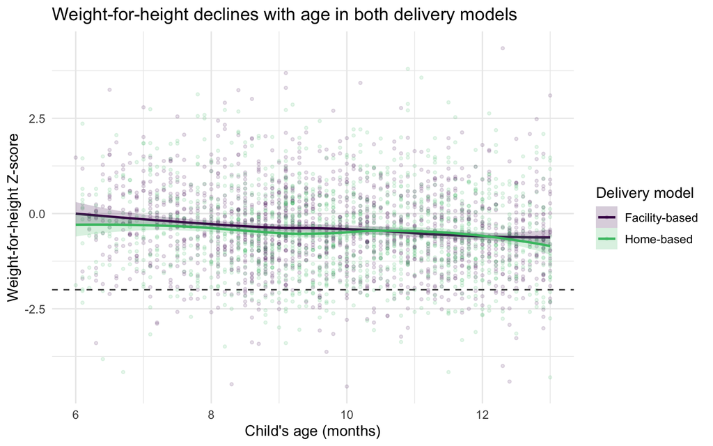

Figure 1. Weight-for-height Z-score against child age, by growth-monitoring delivery model. Points are individual children; lines are loess smooths with 95% confidence bands; the dashed line marks the -2 wasting threshold.

## Univariable models

| **Characteristic** | **N** | **Beta** | **95% CI** | **p-value** |
| --- | --- | --- | --- | --- |
| Growth-monitoring delivery model | 3,031 |  |  |  |
| Facility-based |  | — | — |  |
| Home-based |  | -0.08 | -0.16, 0.00 | 0.051 |
| Child's sex | 3,031 |  |  |  |
| Male |  | — | — |  |
| Female |  | -0.06 | -0.13, 0.02 | 0.2 |
| Child's age (months) | 3,031 | -0.07 | -0.09, -0.05 | <0.001 |
| Mother's age (years) | 3,031 | -0.01 | -0.02, -0.01 | <0.001 |
| Mother's schooling (years) | 3,031 | 0.04 | 0.03, 0.05 | <0.001 |
| Household asset index tertile | 3,031 |  |  |  |
| Lowest |  | — | — |  |
| Middle |  | 0.13 | 0.03, 0.22 | 0.009 |
| Highest |  | 0.33 | 0.24, 0.43 | <0.001 |
| Mother is an NGO member | 3,031 |  |  |  |
| No |  | — | — |  |
| Yes |  | -0.06 | -0.13, 0.02 | 0.2 |
| Improved toilet facility | 3,031 |  |  |  |
| No |  | — | — |  |
| Yes |  | 0.14 | -0.02, 0.29 | 0.087 |

Abbreviation: CI = Confidence Interval

Unadjusted, household wealth is again the strongest correlate: children in the highest asset tertile score 0.334 (95% CI 0.239 to 0.429) Z-units above the lowest tertile (p < 0.001). Each additional year of maternal schooling is associated with 0.040 (95% CI 0.029 to 0.050) (p < 0.001) — noticeably weaker than the same slope for height-for-age, consistent with education acting mainly on chronic rather than acute deficit. Weight-for-height falls with child age (-0.073 (95% CI -0.095 to -0.051) per month, p < 0.001) and with mother’s age (-0.013 (95% CI -0.020 to -0.006), p < 0.001). The programme variable sits exactly on the conventional threshold: children in home-based areas score -0.078 (95% CI -0.156 to 0.000) relative to facility-based areas (p = 0.051). Child sex (p = 0.164), NGO membership (p = 0.159) and improved toilet (p = 0.087) are not significant crude.

## Why adjustment is needed

**Household asset tertile** is the dominant confounder in this dataset. It predicts maternal schooling, latrine ownership and NGO membership on one side, and food security and illness exposure — hence weight-for-height — on the other, so every socio-economic crude estimate here is partly a wealth estimate. **Mother’s schooling** confounds in the reverse direction: better-educated mothers live in wealthier households, so the crude asset gradient contains an education component. **Improved toilet facility** is a third: sanitation is concentrated in wealthier households (93% coverage overall) and poor sanitation causes the diarrhoeal illness that produces acute weight loss, so its crude coefficient cannot be interpreted without holding wealth constant. **Child age** must be adjusted for on structural grounds, because weight-for-height declines appreciably even over the seven months observed here. Adjustment matters particularly for the delivery-model comparison: although the study allocated delivery models to matched-pair areas, the two arms are not perfectly balanced on asset tertile (the highest tertile is slightly over-represented in home-based areas), so the crude programme contrast carries a wealth imbalance with it.

## Multivariable model

| **Characteristic** | **Beta** | **95% CI** | **p-value** |
| --- | --- | --- | --- |
| Growth-monitoring delivery model |  |  |  |
| Facility-based | — | — |  |
| Home-based | -0.09 | -0.17, -0.01 | 0.032 |
| Child's sex |  |  |  |
| Male | — | — |  |
| Female | -0.06 | -0.13, 0.02 | 0.14 |
| Child's age (months) | -0.07 | -0.09, -0.05 | <0.001 |
| Mother's age (years) | -0.01 | -0.01, 0.00 | 0.057 |
| Mother's schooling (years) | 0.03 | 0.02, 0.04 | <0.001 |
| Household asset index tertile |  |  |  |
| Lowest | — | — |  |
| Middle | 0.09 | -0.01, 0.18 | 0.064 |
| Highest | 0.26 | 0.16, 0.36 | <0.001 |
| Mother is an NGO member |  |  |  |
| No | — | — |  |
| Yes | 0.01 | -0.08, 0.09 | 0.9 |
| Improved toilet facility |  |  |  |
| No | — | — |  |
| Yes | 0.00 | -0.16, 0.16 | >0.9 |

Abbreviation: CI = Confidence Interval

Model fit

| Statistic | Value |
| --- | --- |
| R-squared | 0.0423 |
| Adjusted R-squared | 0.0394 |
| Residual SE | 1.076 |
| Observations | 3,031 |
| Model parameters (excl. intercept) | 9 |

The model explains only 4.2% of the variance in weight-for-height (adjusted R-squared 0.039) — the weakest fit of the three Z-score outcomes, which fits the interpretation that acute thinness is driven by short-term shocks that this survey did not measure. Holding the other predictors constant, children in the highest asset tertile score 0.259 (95% CI 0.158 to 0.360) above the lowest (p < 0.001); each extra year of maternal schooling adds 0.028 (95% CI 0.016 to 0.040) (p < 0.001); and each additional month of age is associated with -0.073 (95% CI -0.095 to -0.051) (p < 0.001). Adjusted for household circumstances, children in home-based GMP areas score -0.090 (95% CI -0.171 to -0.008) relative to facility-based areas (p = 0.032). That result should be treated with considerable caution — see the limitations on clustering below.

## Unadjusted versus adjusted

**Table 2. Unadjusted and adjusted estimates.**

| **Characteristic** | **Unadjusted** **N** | **Unadjusted** **Beta** | **Unadjusted** **95% CI** | **Unadjusted** **p-value** | **Adjusted** **Beta** | **Adjusted** **95% CI** | **Adjusted** **p-value** |
| --- | --- | --- | --- | --- | --- | --- | --- |
| Growth-monitoring delivery model | 3,031 |  |  |  |  |  |  |
| Facility-based |  | — | — |  | — | — |  |
| Home-based |  | -0.08 | -0.16, 0.00 | 0.051 | -0.09 | -0.17, -0.01 | 0.032 |
| Child's sex | 3,031 |  |  |  |  |  |  |
| Male |  | — | — |  | — | — |  |
| Female |  | -0.06 | -0.13, 0.02 | 0.2 | -0.06 | -0.13, 0.02 | 0.14 |
| Child's age (months) | 3,031 | -0.07 | -0.09, -0.05 | <0.001 | -0.07 | -0.09, -0.05 | <0.001 |
| Mother's age (years) | 3,031 | -0.01 | -0.02, -0.01 | <0.001 | -0.01 | -0.01, 0.00 | 0.057 |
| Mother's schooling (years) | 3,031 | 0.04 | 0.03, 0.05 | <0.001 | 0.03 | 0.02, 0.04 | <0.001 |
| Household asset index tertile | 3,031 |  |  |  |  |  |  |
| Lowest |  | — | — |  | — | — |  |
| Middle |  | 0.13 | 0.03, 0.22 | 0.009 | 0.09 | -0.01, 0.18 | 0.064 |
| Highest |  | 0.33 | 0.24, 0.43 | <0.001 | 0.26 | 0.16, 0.36 | <0.001 |
| Mother is an NGO member | 3,031 |  |  |  |  |  |  |
| No |  | — | — |  | — | — |  |
| Yes |  | -0.06 | -0.13, 0.02 | 0.2 | 0.01 | -0.08, 0.09 | 0.9 |
| Improved toilet facility | 3,031 |  |  |  |  |  |  |
| No |  | — | — |  | — | — |  |
| Yes |  | 0.14 | -0.02, 0.29 | 0.087 | 0.00 | -0.16, 0.16 | >0.9 |

Abbreviation: CI = Confidence Interval

The interesting movement here runs in both directions. **One predictor moved *away* from the null and gained significance**: the home-based versus facility-based difference went from -0.078 (95% CI -0.156 to 0.000) (p = 0.051) to -0.090 (95% CI -0.171 to -0.008) (p = 0.032). This is negative confounding: home-based areas contain slightly wealthier households, which was masking a small deficit, and holding wealth constant unmasks it. **Two predictors moved toward the null and lost significance.** Maternal schooling attenuated from 0.040 (95% CI 0.029 to 0.050) to 0.028 (95% CI 0.016 to 0.040), a 30% reduction (still significant); mother’s age went from -0.013 (95% CI -0.020 to -0.006) (p < 0.001) to -0.007 (95% CI -0.014 to 0.000) (p = 0.057); and the middle-versus-lowest asset contrast lost significance, 0.126 (95% CI 0.031 to 0.220) (p = 0.009) to 0.089 (95% CI -0.005 to 0.184) (p = 0.064). **Improved toilet collapsed to nothing**, from 0.137 (95% CI -0.020 to 0.294) to -0.002 (95% CI -0.160 to 0.156) — its crude association was entirely a wealth proxy. **Child sex and child age barely moved** (age -0.073 (95% CI -0.095 to -0.051) to -0.073 (95% CI -0.095 to -0.051), sex -0.056 (95% CI -0.134 to 0.023) to -0.058 (95% CI -0.135 to 0.018)), as expected for variables not determined by household circumstances. None of this is collinearity: all variance inflation factors are under 1.3.

## Diagnostics

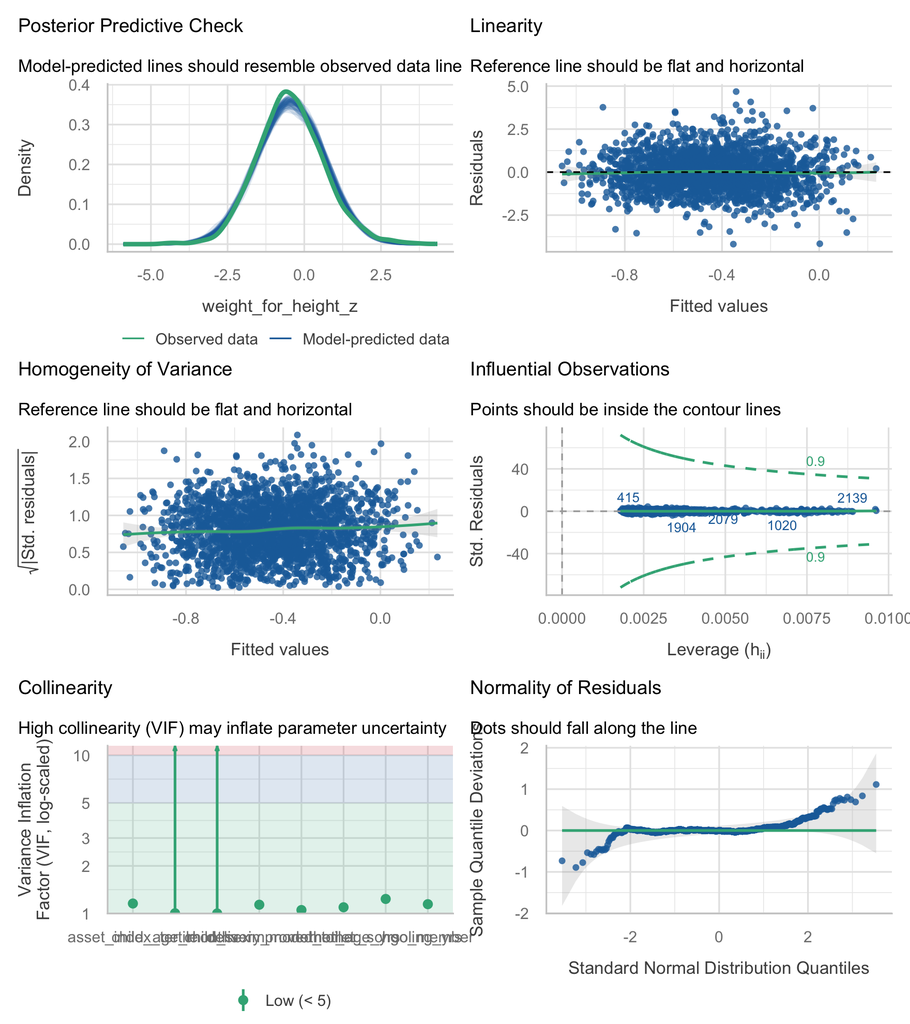

Variance inflation factors

| Term | VIF |
| --- | --- |
| delivery_model | 1.14 |
| child_sex | 1.00 |
| child_age_months | 1.00 |
| mother_age_yrs | 1.10 |
| mother_schooling_yrs | 1.24 |
| asset_index_tertile | 1.16 |
| ngo_member | 1.15 |
| improved_toilet | 1.05 |

The *posterior predictive check* reproduces the observed weight-for-height distribution well. *Linearity* is satisfied — the residual smooth is flat, so linear terms for age and schooling are adequate. *Homogeneity of variance* holds across the fitted range. The *normality of residuals* Q-Q plot is close to the line through the body of the distribution with modest departure in both tails, partly reflecting the severe-malnutrition exclusion truncating the left tail and a few implausibly high Z-scores (above +4) on the right; neither threatens inference at this sample size. No observation crosses the Cook’s-distance contours in the *influential observations* panel. *Collinearity* is fine as specified, but only because `sub_district` was deliberately excluded.

# Discussion

**Limitations.**

*Clustering cannot be modelled, and this outcome is where that bites hardest.* Delivery model is an **area-level** exposure assigned to whole upazilas — six of them — with 60 community-clinic catchment areas sampled as matched pairs. Children in the same catchment share fieldworkers, scales, clinics and food markets, so their weight-for-height values are correlated. The file carries no clinic or cluster identifier, so no random effect or cluster-robust standard error is possible. The nominally significant adjusted delivery-model result (p = 0.032) rests on a standard error computed as though 3031 children were independent when the effective number of independent units is closer to 60, or arguably six. Even a modest design effect would push that interval back across zero. `sub_district` is not a usable substitute cluster variable because it is collinear with the exposure. **This single result should not be reported as a finding.**

*The outcome distribution is truncated by design.* The source paper states that children with severe stunting, wasting or underweight were excluded on ethical grounds so they could be referred for treatment. Yet the shipped file contains 26 children with weight-for-height below -3 and 203 with height-for-age below -3, so the exclusion was incomplete or applied on some other criterion. The lower tail of weight-for-height has therefore been interfered with: the 7.2% wasting prevalence observed here understates the true burden, and coefficients describing movement into the thinnest part of the distribution are attenuated.

*Age definition is inconsistent in the source.* The paper’s abstract says children “under one year”, its methods say 6-23 months, and the data run 6.0 to 13.0 months. We describe the observed range only.

*Design and residual confounding.* Cross-sectional data give associations, not effects. Weight-for-height is the index most sensitive to *recent* events — diarrhoea in the last fortnight, a seasonal food gap, a feeding interruption — and none of these were recorded. Season of measurement is also unavailable, which matters because wasting in Bangladesh is strongly seasonal. Adjusted R-squared of 0.039 is the honest consequence.

*Sparse and dropped variables.* `mother_occupation` and `religion_muslim` were excluded as near-constant.

**Future work.** Repeated measurement across seasons, with cluster identifiers and recent-illness histories, would be needed before any statement about GMP delivery and acute undernutrition could be taken seriously.

# Feasibility notes

*Not part of a student report.*

Near-constant predictors, added back

n = 77 non-housewives, 66 non-Muslim households

| term | estimate | conf.low | conf.high | p.value |
| --- | --- | --- | --- | --- |
| mother_occupationOther | -0.141 | -0.390 | 0.109 | 0.269 |
| religion_muslimMuslim | -0.241 | -0.504 | 0.022 | 0.073 |

Wide, unstable intervals resting on tiny comparison groups. Shown only to justify dropping them.

6. **Overlap with the `wasting` analysis.** Same measurement, dichotomised. The continuous version is strictly more powerful; a student choosing `wasting` instead should know they are giving up power for interpretability.